# Machine Learning with caret

Helper functions include: * data splitting  
* pre-processing  
* feature selection  
* model tuning using resampling  
* variable importance estimation

This script explores caret’s capabilities using a cell segmentation data set that is included in the package. The data is described in the paper: Hill et al “Impact of image segmentation on high-content screening data quality for SK-BR-3 cells” BMC fioinformatics (2007) vol 8 (1) pp. 340

The analysis presented here is based on examples presented by Max Kuhn, caret’s author, at Use-R 2012.

### Background

“Well-segmented”" cells are cells for which location and size may be accurrately detremined through optical measurements. Cells that are not Well-segmented (WS) are said to be “Poorly-segmented”" (PS). Given a set of optical measurements can we predict which cells will be PS? This is a classic classification problem

### Packages Required

```r
library(caret)
library(corrplot)           # plot correlations
library(doParallel)     # parallel processing
library(dplyr)         # Used by caret
library(gbm)                  # Boosting algorithms
library(kernlab)      # support vector machine
library(partykit)           # Plotting trees
library(pROC)                 # plot the ROC curve
library(rpart)              # CART algorithm for decision trees
```

### Get the Data

Load the data and construct indices to divied it into training and test data sets.

```r
data(segmentationData)      # Load the segmentation data set
dim(segmentationData)
```

```
[1] 2019   61
```

```r
head(segmentationData,2)
```

|  | Cell | Case | Class | AngleCh1 | AreaCh1 | AvgIntenCh1 | AvgIntenCh2 | AvgIntenCh3 | AvgIntenCh4 | ConvexHullAreaRatioCh1 | ConvexHullPerimRatioCh1 | DiffIntenDensityCh1 | DiffIntenDensityCh3 | DiffIntenDensityCh4 | EntropyIntenCh1 | EntropyIntenCh3 | EntropyIntenCh4 | EqCircDiamCh1 | EqEllipseLWRCh1 | EqEllipseOblateVolCh1 | EqEllipseProlateVolCh1 | EqSphereAreaCh1 | EqSphereVolCh1 | FiberAlign2Ch3 | FiberAlign2Ch4 | FiberLengthCh1 | FiberWidthCh1 | IntenCoocASMCh3 | IntenCoocASMCh4 | … |
| --- | --- | --- | --- | --- | --- | --- | --- | --- | --- | --- | --- | --- | --- | --- | --- | --- | --- | --- | --- | --- | --- | --- | --- | --- | --- | --- | --- | --- | --- | --- |
| 1 | 207827637 | Test | PS | 143.2477 | 185 | 15.71186 | 4.954802 | 9.548023 | 2.214689 | 1.124509 | 0.9196827 | 29.51923 | 13.77564 | 6.826923 | 4.969781 | 4.371017 | 2.718884 | 15.36954 | 3.060676 | 336.9691 | 110.0963 | 742.1156 | 1900.996 | 1.000000 | 1.000000 | 26.98132 | 7.410365 | 0.01118390 | 0.05044801 | … |
| 2 | 207932307 | Train | PS | 133.7520 | 819 | 31.92327 | 206.878517 | 69.916880 | 164.153453 | 1.263158 | 0.7970801 | 31.87500 | 43.12228 | 79.308424 | 6.087592 | 6.642761 | 7.880155 | 32.30558 | 1.558394 | 2232.9055 | 1432.8246 | 3278.7256 | 17653.525 | 1.487935 | 1.352374 | 64.28230 | 13.167079 | 0.02805106 | 0.01259498 | … |

```r
#
trainIndex <- createDataPartition(segmentationData$Case,p=.5,list=FALSE)
trainData <- segmentationData[trainIndex,-c(1,2)]
testData  <- segmentationData[-trainIndex,-c(1,2)]
#
trainX <-trainData[,-1]        # Pull out the dependent variable
testX <- testData[,-1]
sapply(trainX,summary) # Look at a summary of the training data
```

```
         AngleCh1 AreaCh1 AvgIntenCh1 AvgIntenCh2 AvgIntenCh3 AvgIntenCh4 ConvexHullAreaRatioCh1 ConvexHullPerimRatioCh1
Min.      0.04841   150.0       15.16        1.00      0.2205      0.6316                  1.006                  0.5320
1st Qu.  53.47000   189.0       35.65       45.54     33.1800     40.0100                  1.058                  0.8558
Median   90.76000   248.0       65.03      177.30     67.2600     92.9300                  1.143                  0.9170
Mean     90.76000   313.5      127.00      190.90     96.6900    138.5000                  1.197                  0.8973
3rd Qu. 126.20000   349.8      145.00      286.30    129.2000    192.3000                  1.281                  0.9583
Max.    179.90000  2186.0     1419.00      826.50    725.2000    809.1000                  2.900                  0.9926
        DiffIntenDensityCh1 DiffIntenDensityCh3 DiffIntenDensityCh4 EntropyIntenCh1 EntropyIntenCh3 EntropyIntenCh4
Min.                  26.73               1.414               2.605           4.872          0.2684           0.512
1st Qu.               43.52              28.300              31.480           6.038          4.5010           4.578
Median                56.46              54.550              61.500           6.586          5.7790           5.762
Mean                  72.58              74.410              86.430           6.577          5.4200           5.471
3rd Qu.               81.37              99.810             114.300           7.046          6.5700           6.640
Max.                 355.00             470.700             464.700           9.476          8.0130           7.979
        EqCircDiamCh1 EqEllipseLWRCh1 EqEllipseOblateVolCh1 EqEllipseProlateVolCh1 EqSphereAreaCh1 EqSphereVolCh1
Min.            13.86           1.009                 146.5                  63.85           603.8           1395
1st Qu.         15.54           1.416                 270.5                 147.30           758.9           1966
Median          17.78           1.803                 416.9                 218.80           993.7           2945
Mean            19.27           2.050                 682.0                 354.60          1256.0           4767
3rd Qu.         21.10           2.390                 716.7                 369.00          1399.0           4922
Max.            52.76           9.131                9617.0                6315.00          8746.0          76910
        FiberAlign2Ch3 FiberAlign2Ch4 FiberLengthCh1 FiberWidthCh1 IntenCoocASMCh3 IntenCoocASMCh4 IntenCoocContrastCh3
Min.             1.000          1.000          11.87         4.530        0.004926        0.005255              0.01627
1st Qu.          1.285          1.263          20.12         7.357        0.010200        0.016810              4.26000
Median           1.473          1.459          28.51         9.601        0.041250        0.052680              8.24700
Mean             1.453          1.434          33.71        10.350        0.104100        0.100100              9.67500
3rd Qu.          1.649          1.631          39.65        12.750        0.133500        0.120400             13.79000
Max.             2.000          2.000         160.40        33.170        0.936600        0.867800             59.05000
        IntenCoocContrastCh4 IntenCoocEntropyCh3 IntenCoocEntropyCh4 IntenCoocMaxCh3 IntenCoocMaxCh4 KurtIntenCh1
Min.                 0.03444              0.2546              0.4901         0.01435         0.01342     -1.40300
1st Qu.              3.99800              4.9890              4.9780         0.05344         0.10390     -0.49260
Median               6.40700              6.2930              6.0180         0.19400         0.22010      0.01059
Mean                 7.90100              5.8280              5.7200         0.23940         0.25040      0.73930
3rd Qu.             10.07000              7.0670              6.8340         0.36340         0.34800      0.89490
Max.                61.56000              8.0680              7.9490         0.96830         0.93570     38.97000
        KurtIntenCh3 KurtIntenCh4 LengthCh1 NeighborAvgDistCh1 NeighborMinDistCh1 NeighborVarDistCh1 PerimCh1 ShapeBFRCh1
Min.        -1.35200      -1.5570     14.90              150.3              10.08              60.59    47.49      0.1944
```

[output cut: 19 more lines]

Look at the correlations for the independent variables

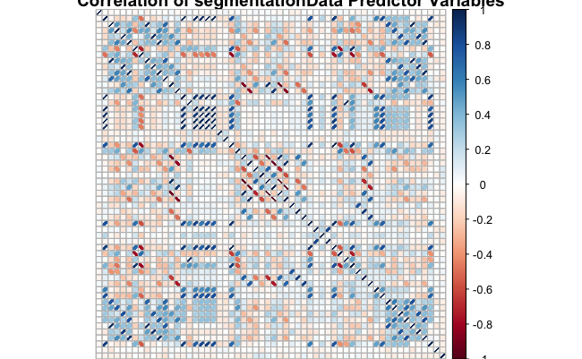

```r
corrplot(cor(trainX),
         method="ellipse",
         tl.pos="n",
         title="Correlation of segmentationData Predictor Variables")
```

## GENERALIZED BOOSTED REGRGRESSION MODEL

We build a gbm model. Note that the gbm function does not allow factor “class” variables

|  | var | rel.inf |
| --- | --- | --- |
| TotalIntenCh2 | TotalIntenCh2 | 18.9591038 |
| FiberWidthCh1 | FiberWidthCh1 | 7.3697618 |
| AvgIntenCh1 | AvgIntenCh1 | 4.2888969 |
| AvgIntenCh2 | AvgIntenCh2 | 3.7158724 |
| TotalIntenCh1 | TotalIntenCh1 | 3.2145131 |
| ConvexHullPerimRatioCh1 | ConvexHullPerimRatioCh1 | 3.1076151 |
| ShapeP2ACh1 | ShapeP2ACh1 | 2.8206727 |
| EntropyIntenCh1 | EntropyIntenCh1 | 2.3978325 |
| VarIntenCh4 | VarIntenCh4 | 2.2998653 |
| NeighborAvgDistCh1 | NeighborAvgDistCh1 | 2.1163860 |

[output cut: 48 more lines]

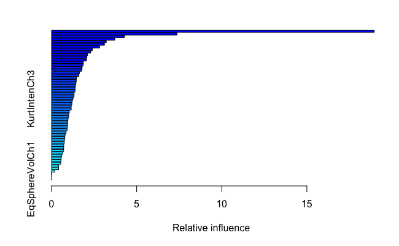

```r
gbmTrain <- trainData
gbmTrain$Class <- ifelse(gbmTrain$Class=="PS",1,0)
gbm.mod <- gbm(formula = Class~.,           # use all variables
                distribution = "bernoulli",       # for a classification problem
                data = gbmTrain,
                n.trees = 2000,                         # 2000 boosting iterations
                interaction.depth = 7,              # 7 splits for each tree
                shrinkage = 0.01,                       # the learning rate parameter
                verbose = FALSE)                        # Do not print the details

summary(gbm.mod)            # Plot the relative inference of the variables in the model
```

This is an interesting model, but how do you select the best values for the for the three tuning parameters?  
* n.trees  
* interaction.depth  
* shrinkage

### GBM Model Training Over Paramter Space

caret provides the “train” function that implements the following algorithm:

Algorithm for training the model:  
Define sets of model parameters to evaluate  
for each parameter set do  
….for each resampling iteration do  
……hold out specific samples  
……pre-process the data  
……fit the model to the remainder  
….predict the holdout samples  
….end  
….calculate the average performance across hold-out predictions  
end  
Determine the optimal parameter set  
Fit the final model to the training data using the optimal parameter set

Note the default method of picking the best model is accuracy and Cohen’s Kappa

```r
# Set up training control
ctrl <- trainControl(method="repeatedcv",   # 10fold cross validation
                     repeats=5,                                   # do 5 repititions of cv
                     summaryFunction=twoClassSummary,   # Use AUC to pick the best model
                     classProbs=TRUE)
```

Use the expand.grid to specify the search space Note that the default search grid selects 3 values of each tuning parameter

```r
grid <- expand.grid(interaction.depth = seq(1,4,by=2), #tree depths from 1 to 4
                    n.trees=seq(10,100,by=10),  # let iterations go from 10 to 100
                    shrinkage=c(0.01,0.1),          # Try 2 values fornlearning rate
                    n.minobsinnode = 20)
#
set.seed(1951)                     # set the seed to 1
```

Set up to to do parallel processing

```r
registerDoParallel(4)       # Registrer a parallel backend for train
getDoParWorkers()
```

```
[1] 4
```

```r
system.time(gbm.tune <- train(x=trainX,y=trainData$Class,
                method = "gbm",
                metric = "ROC",
                trControl = ctrl,
                tuneGrid=grid,
                verbose=FALSE))
```

```
   user  system elapsed
 39.109   1.897  21.580
```

Look at the tuning results Note that ROC was the performance criterion used to select the optimal model.

```r
gbm.tune$bestTune
```

|  | n.trees | interaction.depth | shrinkage | n.minobsinnode |
| --- | --- | --- | --- | --- |
| 38 | 80 | 3 | 0.1 | 20 |

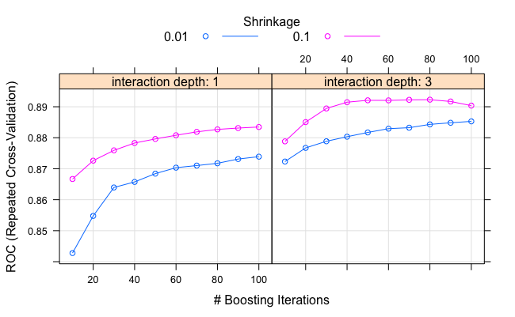

```r
plot(gbm.tune)          # Plot the performance of the training models
```

```r
res <- gbm.tune$results
names(res) <- c("depth","trees", "shrinkage","ROC", "Sens","Spec", "sdROC", "sdSens", "seSpec")
res
```

|  | depth | trees | shrinkage | ROC | Sens | Spec | sdROC | sdSens | seSpec | None |
| --- | --- | --- | --- | --- | --- | --- | --- | --- | --- | --- |
| 1 | 0.01 | 1 | 20 | 10 | 0.8427830 | 1.0000000 | 0.00000000 | 0.03700625 | 0.00000000 | 0.00000000 |
| 21 | 0.10 | 1 | 20 | 10 | 0.8666862 | 0.9196020 | 0.47808403 | 0.03355412 | 0.03415972 | 0.09641236 |
| 11 | 0.01 | 3 | 20 | 10 | 0.8723170 | 1.0000000 | 0.00000000 | 0.03220320 | 0.00000000 | 0.00000000 |
| 31 | 0.10 | 3 | 20 | 10 | 0.8788265 | 0.8945138 | 0.63509244 | 0.03362095 | 0.03788986 | 0.07896725 |
| 2 | 0.01 | 1 | 20 | 20 | 0.8547712 | 1.0000000 | 0.00000000 | 0.03737024 | 0.00000000 | 0.00000000 |
| 22 | 0.10 | 1 | 20 | 20 | 0.8726095 | 0.8815694 | 0.62766387 | 0.03278105 | 0.03521216 | 0.08088383 |
| 12 | 0.01 | 3 | 20 | 20 | 0.8767241 | 1.0000000 | 0.00000000 | 0.03307645 | 0.00000000 | 0.00000000 |
| 32 | 0.10 | 3 | 20 | 20 | 0.8850455 | 0.8742786 | 0.68860504 | 0.03326851 | 0.03730011 | 0.06927034 |
| 3 | 0.01 | 1 | 20 | 30 | 0.8639495 | 1.0000000 | 0.00000000 | 0.03351046 | 0.00000000 | 0.00000000 |
| 23 | 0.10 | 1 | 20 | 30 | 0.8759312 | 0.8721891 | 0.66383193 | 0.03491426 | 0.04001149 | 0.06936323 |

[output cut: 30 more lines]

### GBM Model Predictions and Performance

Make predictions using the test data set

```r
gbm.pred <- predict(gbm.tune,testX)
head(gbm.pred)
```

```
[1] PS WS PS PS PS PS
Levels: PS WS
```

Look at the confusion matrix

```r
confusionMatrix(gbm.pred,testData$Class)
```

```
Confusion Matrix and Statistics

          Reference
Prediction  PS  WS
        PS 562 106
        WS  76 265

               Accuracy : 0.8196
                 95% CI : (0.7945, 0.8429)
    No Information Rate : 0.6323
    P-Value [Acc > NIR] : < 2e-16

                  Kappa : 0.6054
 Mcnemar's Test P-Value : 0.03159

            Sensitivity : 0.8809
            Specificity : 0.7143
         Pos Pred Value : 0.8413
         Neg Pred Value : 0.7771
             Prevalence : 0.6323
         Detection Rate : 0.5570
   Detection Prevalence : 0.6620
      Balanced Accuracy : 0.7976

       'Positive' Class : PS
```

Draw the ROC curve

```r
gbm.probs <- predict(gbm.tune,testX,type="prob")
head(gbm.probs)
```

|  | PS | WS |
| --- | --- | --- |
| 1 | 0.97661341 | 0.02338659 |
| 2 | 0.03175595 | 0.96824405 |
| 3 | 0.96013485 | 0.03986515 |
| 4 | 0.92140685 | 0.07859315 |
| 5 | 0.85633058 | 0.14366942 |
| 6 | 0.88737921 | 0.11262079 |

```r
gbm.ROC <- roc(predictor=gbm.probs$PS,
            response=testData$Class,
                levels=rev(levels(testData$Class)))
gbm.ROC
```

```
Call:
roc.default(response = testData$Class, predictor = gbm.probs$PS,     levels = rev(levels(testData$Class)))

Data: gbm.probs$PS in 371 controls (testData$Class WS) < 638 cases (testData$Class PS).
Area under the curve: 0.8975
```

```
Call:
roc.default(response = testData$Class, predictor = gbm.probs$PS,     levels = rev(levels(testData$Class)))

Data: gbm.probs$PS in 371 controls (testData$Class WS) < 638 cases (testData$Class PS).
Area under the curve: 0.8975
```

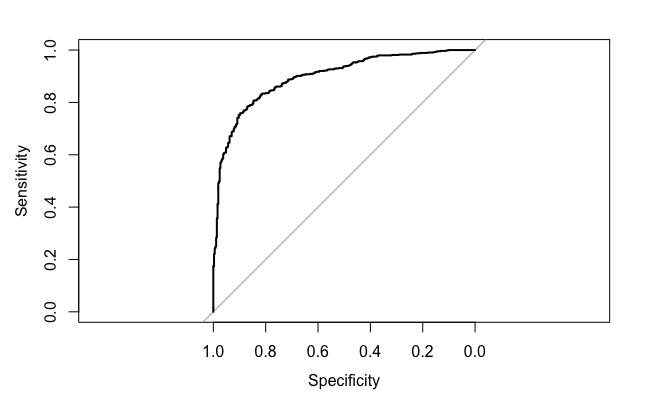

```r
plot(gbm.ROC)
```

Plot the propability of poor segmentation

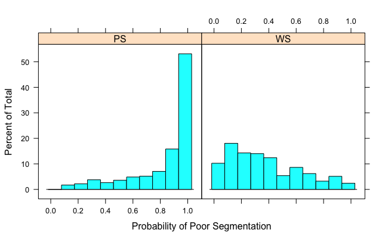

```r
histogram(~gbm.probs$PS|testData$Class,xlab="Probability of Poor Segmentation")
```

## SUPPORT VECTOR MACHINE MODEL

We follow steps similar to those above to build a SVM model

```r
# Set up for parallel procerssing
set.seed(1951)
registerDoParallel(4,cores=4)
getDoParWorkers()
```

```
[1] 4
```

Train and Tune the SVM

```r
system.time(
  svm.tune <- train(x=trainX,
                    y= trainData$Class,
                    method = "svmRadial",
                    tuneLength = 9,                 # 9 values of the cost function
                    preProc = c("center","scale"),
                    metric="ROC",
                    trControl=ctrl) # same as for gbm above
)
```

```
   user  system elapsed
218.804  15.123  83.633
```

```r
svm.tune
```

```
Support Vector Machines with Radial Basis Function Kernel

1010 samples
  58 predictor
   2 classes: 'PS', 'WS'

Pre-processing: centered (58), scaled (58)
Resampling: Cross-Validated (10 fold, repeated 5 times)
Summary of sample sizes: 909, 909, 909, 909, 909, 909, ...
Resampling results across tuning parameters:

  C      ROC        Sens       Spec
   0.25  0.8728529  0.8730801  0.6425882
   0.50  0.8759912  0.8760877  0.6546050
   1.00  0.8790522  0.8833559  0.6712437
   2.00  0.8767267  0.8815332  0.6724706
   4.00  0.8682961  0.8791090  0.6569412
   8.00  0.8557022  0.8757711  0.6356639
  16.00  0.8443228  0.8782044  0.6075630
  32.00  0.8295481  0.8685391  0.5743193
  64.00  0.8193950  0.8667164  0.5506891

Tuning parameter 'sigma' was held constant at a value of 0.01461449
ROC was used to select the optimal model using  the largest value.
The final values used for the model were sigma = 0.01461449 and C = 1.
```

Plot the SVM results

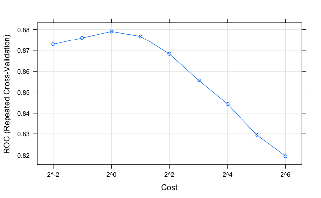

```r
plot(svm.tune,
     metric="ROC",
     scales=list(x=list(log=2)))
```

Make predictions on the test data with the SVM Model

```r
svm.pred <- predict(svm.tune,testX)
head(svm.pred)
```

```
[1] PS WS PS PS PS PS
Levels: PS WS
```

```r
confusionMatrix(svm.pred,testData$Class)
```

```
Confusion Matrix and Statistics

          Reference
Prediction  PS  WS
        PS 578 125
        WS  60 246

               Accuracy : 0.8167
                 95% CI : (0.7914, 0.8401)
    No Information Rate : 0.6323
    P-Value [Acc > NIR] : < 2.2e-16

                  Kappa : 0.5907
 Mcnemar's Test P-Value : 2.534e-06

            Sensitivity : 0.9060
            Specificity : 0.6631
         Pos Pred Value : 0.8222
         Neg Pred Value : 0.8039
             Prevalence : 0.6323
         Detection Rate : 0.5728
   Detection Prevalence : 0.6967
      Balanced Accuracy : 0.7845

       'Positive' Class : PS
```

```r
svm.probs <- predict(svm.tune,testX,type="prob")
head(svm.probs)
```

|  | PS | WS |
| --- | --- | --- |
| 1 | 0.86134551 | 0.13865449 |
| 2 | 0.07609013 | 0.92390987 |
| 3 | 0.95612598 | 0.04387402 |
| 4 | 0.80238298 | 0.19761702 |
| 5 | 0.81207786 | 0.18792214 |
| 6 | 0.87123434 | 0.12876566 |

```r
svm.ROC <- roc(predictor=svm.probs$PS,
               response=testData$Class,
               levels=rev(levels(testData$Class)))
svm.ROC
```

```
Call:
roc.default(response = testData$Class, predictor = svm.probs$PS,     levels = rev(levels(testData$Class)))

Data: svm.probs$PS in 371 controls (testData$Class WS) < 638 cases (testData$Class PS).
Area under the curve: 0.898
```

```
Call:
roc.default(response = testData$Class, predictor = svm.probs$PS,     levels = rev(levels(testData$Class)))

Data: svm.probs$PS in 371 controls (testData$Class WS) < 638 cases (testData$Class PS).
Area under the curve: 0.898
```

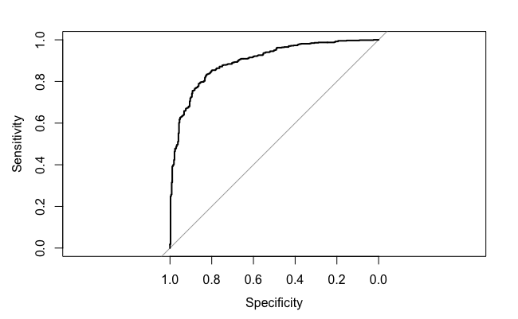

```r
plot(svm.ROC)
```

## RANDOM FOREST MODEL

```r
set.seed(1951)
rf.tune <-train(x=trainX,
                y= trainData$Class,
                method="rf",
                trControl= ctrl,
                prox=TRUE,allowParallel=TRUE)
```

```
1 package is needed for this model and is not installed. (randomForest). Would you like to try to install it now?
1: yes
2: no
```

```r
1
```

```
The metric "Accuracy" was not in the result set. ROC will be used instead.
```

```r
rf.tune
```

```
Random Forest

1010 samples
  58 predictor
   2 classes: 'PS', 'WS'

No pre-processing
Resampling: Cross-Validated (10 fold, repeated 5 times)
Summary of sample sizes: 909, 909, 909, 909, 909, 909, ...
Resampling results across tuning parameters:

  mtry  ROC        Sens       Spec
   2    0.8917444  0.8878743  0.6846555
  30    0.8899825  0.8691633  0.7259664
  58    0.8859384  0.8603844  0.7287899

ROC was used to select the optimal model using  the largest value.
The final value used for the model was mtry = 2.
```

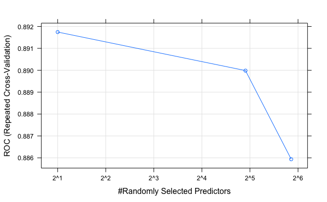

```r
# Plot the Random Forest results
plot(rf.tune,
     metric="ROC",
     scales=list(x=list(log=2)))
```

```r
# Random Forest Predictions
rf.pred <- predict(rf.tune,testX)
head(rf.pred)
```

```
[1] PS WS PS PS PS PS
Levels: PS WS
```

```r
confusionMatrix(rf.pred,testData$Class)
```

```
Confusion Matrix and Statistics

          Reference
Prediction  PS  WS
        PS 568 117
        WS  70 254

               Accuracy : 0.8147
                 95% CI : (0.7893, 0.8382)
    No Information Rate : 0.6323
    P-Value [Acc > NIR] : < 2.2e-16

                  Kappa : 0.5906
 Mcnemar's Test P-Value : 0.0007686

            Sensitivity : 0.8903
            Specificity : 0.6846
         Pos Pred Value : 0.8292
         Neg Pred Value : 0.7840
             Prevalence : 0.6323
         Detection Rate : 0.5629
   Detection Prevalence : 0.6789
      Balanced Accuracy : 0.7875

       'Positive' Class : PS
```

```r
rf.probs <- predict(rf.tune,testX,type="prob")
head(rf.probs)
```

|  | PS | WS |
| --- | --- | --- |
| 1 | 0.896 | 0.104 |
| 7 | 0.092 | 0.908 |
| 8 | 0.940 | 0.060 |
| 10 | 0.822 | 0.178 |
| 12 | 0.750 | 0.250 |
| 15 | 0.804 | 0.196 |

```r
rf.ROC <- roc(predictor=rf.probs$PS,
               response=testData$Class,
               levels=rev(levels(testData$Class)))
rf.ROC
```

```
Call:
roc.default(response = testData$Class, predictor = rf.probs$PS,     levels = rev(levels(testData$Class)))

Data: rf.probs$PS in 371 controls (testData$Class WS) < 638 cases (testData$Class PS).
Area under the curve: 0.9024
```

```
Call:
roc.default(response = testData$Class, predictor = rf.probs$PS,     levels = rev(levels(testData$Class)))

Data: rf.probs$PS in 371 controls (testData$Class WS) < 638 cases (testData$Class PS).
Area under the curve: 0.9024
```

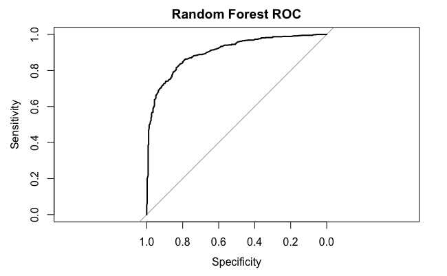

```r
plot(rf.ROC,main = "Random Forest ROC")
```

## Comparing Multiple Models

```r
rValues <- resamples(list(svm=svm.tune,gbm=gbm.tune,rf=rf.tune))
rValues$values
```

| Resample | svm~ROC | svm~Sens | svm~Spec | gbm~ROC | gbm~Sens | gbm~Spec | rf~ROC | rf~Sens | rf~Spec |
| --- | --- | --- | --- | --- | --- | --- | --- | --- | --- |
| Fold01.Rep1 | 0.9464442 | 0.9402985 | 0.6176471 | 0.9578578 | 0.9253731 | 0.7647059 | 0.9615891 | 0.9402985 | 0.7058824 |
| Fold01.Rep2 | 0.8608428 | 0.8656716 | 0.6176471 | 0.8625988 | 0.8507463 | 0.6764706 | 0.8810360 | 0.8656716 | 0.7647059 |
| Fold01.Rep3 | 0.9051948 | 0.9242424 | 0.7142857 | 0.9008658 | 0.8939394 | 0.6857143 | 0.8891775 | 0.9090909 | 0.6285714 |
| Fold01.Rep4 | 0.8667558 | 0.8484848 | 0.7058824 | 0.8796791 | 0.8333333 | 0.7058824 | 0.8870321 | 0.8787879 | 0.6764706 |
| Fold01.Rep5 | 0.8895522 | 0.9253731 | 0.6571429 | 0.9044776 | 0.8955224 | 0.7142857 | 0.9019190 | 0.9402985 | 0.6000000 |
| Fold02.Rep1 | 0.9086580 | 0.8939394 | 0.6857143 | 0.9116883 | 0.8787879 | 0.7714286 | 0.9138528 | 0.8787879 | 0.7428571 |
| Fold02.Rep2 | 0.8809524 | 0.9242424 | 0.6857143 | 0.9082251 | 0.9090909 | 0.7142857 | 0.9041126 | 0.9393939 | 0.6857143 |
| Fold02.Rep3 | 0.8839827 | 0.8939394 | 0.7428571 | 0.8787879 | 0.8484848 | 0.8285714 | 0.8846320 | 0.8939394 | 0.7428571 |
| Fold02.Rep4 | 0.8939394 | 0.9545455 | 0.5588235 | 0.9322638 | 0.9242424 | 0.6764706 | 0.9128788 | 0.9393939 | 0.6176471 |
| Fold02.Rep5 | 0.8896104 | 0.9242424 | 0.6000000 | 0.8961039 | 0.8787879 | 0.6571429 | 0.8958874 | 0.8939394 | 0.6285714 |

[output cut: 40 more lines]

```r
summary(rValues)
```

```
Call:
summary.resamples(object = rValues)

Models: svm, gbm, rf
Number of resamples: 50

ROC
      Min. 1st Qu. Median   Mean 3rd Qu.   Max. NA's
svm 0.7983  0.8610 0.8808 0.8791  0.8954 0.9494    0
gbm 0.7844  0.8789 0.8944 0.8923  0.9108 0.9579    0
rf  0.7996  0.8736 0.8921 0.8917  0.9111 0.9616    0

Sens
      Min. 1st Qu. Median   Mean 3rd Qu.   Max. NA's
svm 0.8030  0.8636 0.8864 0.8834  0.9205 0.9552    0
gbm 0.7879  0.8485 0.8636 0.8674  0.8939 0.9254    0
rf  0.8182  0.8636 0.8873 0.8879  0.9091 0.9545    0

Spec
      Min. 1st Qu. Median   Mean 3rd Qu.   Max. NA's
svm 0.4286  0.6286 0.6857 0.6712  0.7143 0.8286    0
gbm 0.4857  0.6788 0.7353 0.7173  0.7714 0.8286    0
rf  0.4571  0.6286 0.6857 0.6847  0.7429 0.8286    0
```

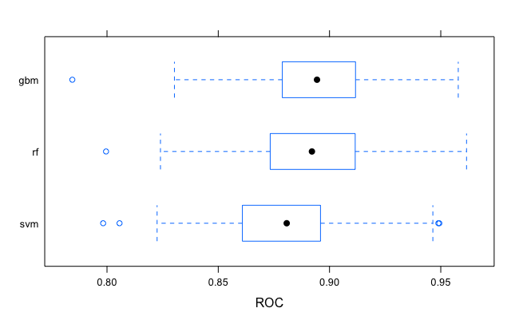

```r
bwplot(rValues,metric="ROC")            # boxplot
```

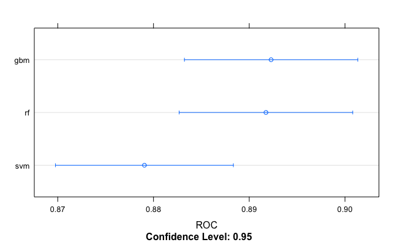

```r
dotplot(rValues,metric="ROC")           # dotplot
```

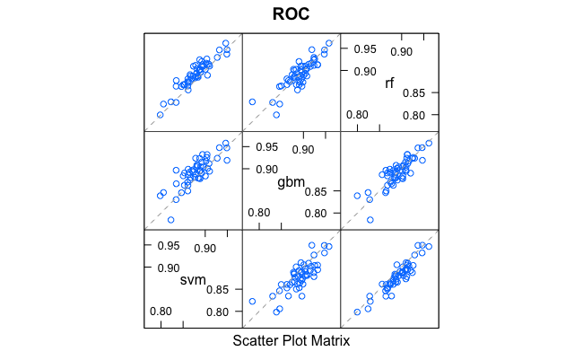

```r
splom(rValues,metric="ROC")
```